# EXAMEN 1 - LABORATORIO Estadistica

Analisis de Estadistica Descriptiva - Pizza Delivery Dataset

Victor Daniel Arango Sohm

2025-08-14

# Carga de datos

```r
# Cargar librerias necesarias
library(ggplot2)
library(dplyr)
library(gridExtra)

# Cargar los datos
datos <- read.csv("pizzadelivery.csv", header = FALSE, stringsAsFactors = FALSE)

# Asignar nombres de columnas
colnames(datos) <- c("id", "day", "date", "time", "operator", "branch",
                     "driver", "temperature", "bill", "pizzas",
                     "free_wine", "got_wine", "discount_customer")

# Convertir variables a tipos apropiados
datos$id <- as.numeric(datos$id)
datos$time <- as.numeric(datos$time)
datos$temperature <- as.numeric(datos$temperature)
datos$bill <- as.numeric(datos$bill)
datos$pizzas <- as.numeric(datos$pizzas)
datos$free_wine <- as.numeric(datos$free_wine)
datos$got_wine <- as.numeric(datos$got_wine)
datos$discount_customer <- as.numeric(datos$discount_customer)

# Convertir variables categoricas
datos$day <- as.factor(datos$day)
datos$operator <- as.factor(datos$operator)
datos$branch <- as.factor(datos$branch)
datos$driver <- as.factor(datos$driver)

# Mostrar estructura de los datos
str(datos)
```

```
## 'data.frame':    1267 obs. of  13 variables:
##  $ id               : num  NA 1 2 3 4 5 6 7 8 9 ...
##  $ day              : Factor w/ 8 levels "day","Friday",..: 1 6 6 6 6 6 6 6 6 6 ...
##  $ date             : chr  "date" "01-May-14" "01-May-14" "01-May-14" ...
##  $ time             : num  NA 35.1 25.2 45.6 29.4 30 40.3 48.7 34 28.2 ...
##  $ operator         : Factor w/ 3 levels "Laura","Melissa",..: 3 1 2 2 2 2 2 1 2 1 ...
##  $ branch           : Factor w/ 4 levels "branch","Centre",..: 1 3 3 4 3 4 2 4 4 2 ...
##  $ driver           : Factor w/ 6 levels "Bruno","Domenico",..: 3 1 6 6 6 6 1 1 5 5 ...
##  $ temperature      : num  NA 68.3 71 53.4 70.3 71.5 60.8 58.3 68.1 64.9 ...
##  $ bill             : num  NA 58.4 26.4 58.1 35.2 38.4 61.8 57.9 35.8 36.6 ...
##  $ pizzas           : num  NA 4 2 3 3 2 4 3 2 2 ...
##  $ free_wine        : num  NA 0 0 1 0 0 1 1 0 0 ...
##  $ got_wine         : num  NA 0 0 0 0 0 1 1 0 0 ...
##  $ discount_customer: num  NA 1 0 0 0 0 0 0 0 0 ...
```

```r
head(datos)
```

```
##   id      day      date time operator branch    driver temperature bill pizzas
## 1 NA      day      date   NA operator branch    driver          NA   NA     NA
## 2  1 Thursday 01-May-14 35.1    Laura   East     Bruno        68.3 58.4      4
## 3  2 Thursday 01-May-14 25.2  Melissa   East Salvatore        71.0 26.4      2
## 4  3 Thursday 01-May-14 45.6  Melissa   West Salvatore        53.4 58.1      3
## 5  4 Thursday 01-May-14 29.4  Melissa   East Salvatore        70.3 35.2      3
## 6  5 Thursday 01-May-14 30.0  Melissa   West Salvatore        71.5 38.4      2
##   free_wine got_wine discount_customer
## 1        NA       NA                NA
## 2         0        0                 1
## 3         0        0                 0
## 4         1        0                 0
## 5         0        0                 0
## 6         0        0                 0
```

# Problema 1: Clasificacion de Variables

## Analisis de Variables

```r
# Crear tabla de clasificacion de variables
clasificacion <- data.frame(
  Variable = c("id", "day", "date", "time", "operator", "branch", "driver",
               "temperature", "bill", "pizzas", "free_wine", "got_wine", "discount_customer"),
  Tipo = c("Cuantitativa", "Categorica", "Categorica", "Cuantitativa",
           "Categorica", "Categorica", "Categorica", "Cuantitativa",
           "Cuantitativa", "Cuantitativa", "Categorica", "Categorica", "Categorica"),
  Subtipo = c("Discreta", "Nominal", "Ordinal", "Continua",
              "Nominal", "Nominal", "Nominal", "Continua",
              "Continua", "Discreta", "Nominal", "Nominal", "Nominal"),
  Descripcion = c("Identificador único", "Dia de la semana", "Fecha del pedido",
                  "Tiempo de entrega (min)", "Operador telefónico", "Sucursal del restaurant",
                  "Repartidor", "Temperatura de entrega (°C)", "Cuenta total (euros)",
                  "Número de pizzas", "Vino gratis (0/1)", "Llevó vino (0/1)", "Cliente con descuento (0/1)")
)

knitr::kable(clasificacion, caption = "Clasificacion de Variables")
```

Clasificacion de Variables

| Variable | Tipo | Subtipo | Descripcion |
| --- | --- | --- | --- |
| id | Cuantitativa | Discreta | Identificador único |
| day | Categorica | Nominal | Dia de la semana |
| date | Categorica | Ordinal | Fecha del pedido |
| time | Cuantitativa | Continua | Tiempo de entrega (min) |
| operator | Categorica | Nominal | Operador telefónico |
| branch | Categorica | Nominal | Sucursal del restaurant |
| driver | Categorica | Nominal | Repartidor |
| temperature | Cuantitativa | Continua | Temperatura de entrega (°C) |
| bill | Cuantitativa | Continua | Cuenta total (euros) |
| pizzas | Cuantitativa | Discreta | Número de pizzas |
| free_wine | Categorica | Nominal | Vino gratis (0/1) |
| got_wine | Categorica | Nominal | Llevó vino (0/1) |
| discount_customer | Categorica | Nominal | Cliente con descuento (0/1) |

# Problema 2: Analisis de la Variable “day”

```r
# Analisis de frecuencias para day
freq_day <- table(datos$day)
prop_day <- prop.table(freq_day)

# Crear tabla de frecuencias
tabla_day <- data.frame(
  Dia = names(freq_day),
  Frecuencia_Absoluta = as.numeric(freq_day),
  Frecuencia_Relativa = round(as.numeric(prop_day), 4),
  Porcentaje = round(as.numeric(prop_day) * 100, 2)
)

knitr::kable(tabla_day, caption = "Tabla de Frecuencias - Variable Day")
```

Tabla de Frecuencias - Variable Day

| Dia | Frecuencia_Absoluta | Frecuencia_Relativa | Porcentaje |
| --- | --- | --- | --- |
| day | 1 | 0.0008 | 0.08 |
| Friday | 246 | 0.1942 | 19.42 |
| Monday | 136 | 0.1073 | 10.73 |
| Saturday | 246 | 0.1942 | 19.42 |
| Sunday | 177 | 0.1397 | 13.97 |
| Thursday | 196 | 0.1547 | 15.47 |
| Tuesday | 133 | 0.1050 | 10.50 |
| Wednesday | 132 | 0.1042 | 10.42 |

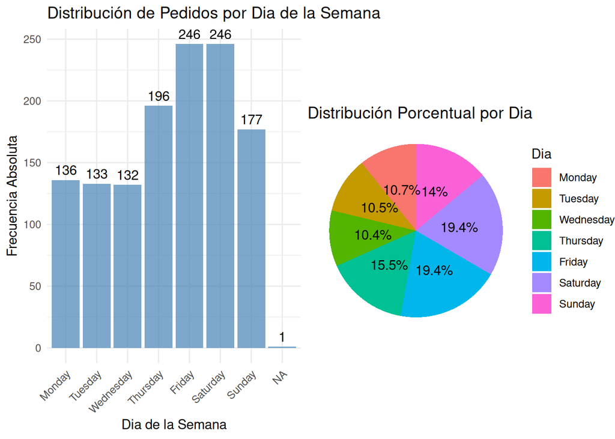

```r
# Ordenar dias de la semana Manualmente
datos$day <- factor(datos$day, levels = c("Monday", "Tuesday", "Wednesday", "Thursday",
                                         "Friday", "Saturday", "Sunday"))

# Grafica de barras
p1 <- ggplot(datos, aes(x = day)) +
  geom_bar(fill = "steelblue", alpha = 0.7) +
  geom_text(stat = "count", aes(label = ..count..), vjust = -0.5) +
  labs(title = "Distribución de Pedidos por Dia de la Semana",
       x = "Dia de la Semana",
       y = "Frecuencia Absoluta") +
  theme_minimal() +
  theme(axis.text.x = element_text(angle = 45, hjust = 1))

# Grafico circular
pie_data <- data.frame(table(datos$day))
colnames(pie_data) <- c("Dia", "Frecuencia")
pie_data$Porcentaje <- round((pie_data$Frecuencia / sum(pie_data$Frecuencia)) * 100, 1)

p2 <- ggplot(pie_data, aes(x = "", y = Frecuencia, fill = Dia)) +
  geom_bar(stat = "identity", width = 1) +
  coord_polar("y", start = 0) +
  labs(title = "Distribución Porcentual por Dia") +
  theme_void() +
  geom_text(aes(label = paste0(Porcentaje, "%")),
            position = position_stack(vjust = 0.5))

grid.arrange(p1, p2, ncol = 2)
```

# Problema 3: Histograma de Time

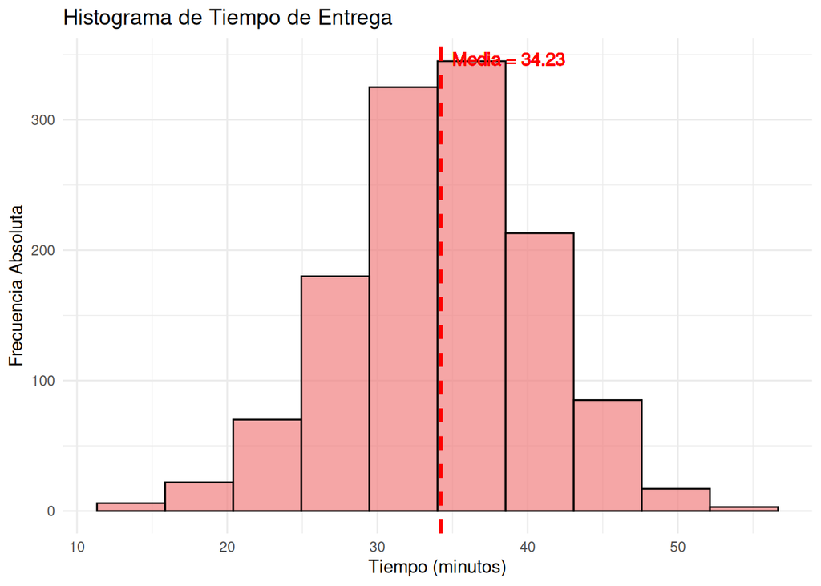

```r
# Estadistica basica de time
media_time <- mean(datos$time, na.rm = TRUE)
mediana_time <- median(datos$time, na.rm = TRUE)

# Histograma con intervalos de clase especificos
hist_time <- ggplot(datos, aes(x = time)) +
  geom_histogram(bins = 10, fill = "lightcoral", alpha = 0.7, color = "black") +
  geom_vline(xintercept = media_time, color = "red", linetype = "dashed", size = 1) +
  geom_text(aes(x = media_time, y = Inf, label = paste("Media =", round(media_time, 2))),
            vjust = 2, hjust = -0.1, color = "red") +
  labs(title = "Histograma de Tiempo de Entrega",
       x = "Tiempo (minutos)",
       y = "Frecuencia Absoluta") +
  theme_minimal()

print(hist_time)
```

```r
# Determinar el intervalo donde se encuentra la media
hist_data <- hist(datos$time, plot = FALSE, breaks = 10)
intervalos <- data.frame(
  Intervalo = paste0("[", round(hist_data$breaks[-length(hist_data$breaks)], 1),
                     ", ", round(hist_data$breaks[-1], 1), ")"),
  Frecuencia = hist_data$counts
)

# Encontrar en que intervalo esta la media
intervalo_media <- which(media_time >= hist_data$breaks[-length(hist_data$breaks)] &
                        media_time < hist_data$breaks[-1])

knitr::kable(intervalos, caption = "Intervalos de Clase - Tiempo de Entrega")
```

Intervalos de Clase - Tiempo de Entrega

| Intervalo | Frecuencia |
| --- | --- |
| [10, 15) | 3 |
| [15, 20) | 21 |
| [20, 25) | 77 |
| [25, 30) | 215 |
| [30, 35) | 374 |
| [35, 40) | 348 |
| [40, 45) | 171 |
| [45, 50) | 51 |
| [50, 55) | 6 |

```r
cat("La media aritmética del tiempo de entrega es:", round(media_time, 2), "minutos")
```

```
## La media aritmética del tiempo de entrega es: 34.23 minutos
```

```r
cat("\nSe encuentra en el intervalo:", intervalos$Intervalo[intervalo_media])
```

```
##
## Se encuentra en el intervalo: [30, 35)
```

**Conclusion Problema 3:** La media del tiempo de entrega (34.23 minutos) se encuentra en el intervalo [30, 35), que es uno de los intervalos con mayor frecuencia en el histograma. Esto indica que la distribucion de tiempos de entrega es relativamente simétrica alrededor de la media.

# Problema 4: Analisis de “temperature”

```r
# Estaiistica descriptiva para temperature
media_temp <- mean(datos$temperature, na.rm = TRUE)
mediana_temp <- median(datos$temperature, na.rm = TRUE)
desv_temp <- sd(datos$temperature, na.rm = TRUE)
coef_var_temp <- (desv_temp / media_temp) * 100

# Funcion para calcular la moda
calcular_moda <- function(x) {
  ux <- unique(x)
  ux[which.max(tabulate(match(x, ux)))]
}
moda_temp <- calcular_moda(datos$temperature)

# Estadisticas adicionales
stats_temp <- data.frame(
  Estadistica = c("Media", "Mediana", "Moda", "Desviacion Estandar", "Coeficiente de Variacion (%)",
                  "Minimo", "Maximo", "Primer Cuartil (Q1)", "Tercer Cuartil (Q3)", "Rango",
                  "Percentil 10", "Percentil 90", "Varianza"),

  Valor = c(round(media_temp, 2), round(mediana_temp, 2), round(moda_temp, 2),
            round(desv_temp, 2), round(coef_var_temp, 2),
            round(min(datos$temperature, na.rm = TRUE), 2),
            round(max(datos$temperature, na.rm = TRUE), 2),
            round(quantile(datos$temperature, 0.25, na.rm = TRUE), 2),
            round(quantile(datos$temperature, 0.75, na.rm = TRUE), 2),
            round(max(datos$temperature, na.rm = TRUE) - min(datos$temperature, na.rm = TRUE), 2),
            round(quantile(datos$temperature, 0.10, na.rm = TRUE), 2),
            round(quantile(datos$temperature, 0.90, na.rm = TRUE), 2),
            round(var(datos$temperature, na.rm = TRUE), 2))
)

knitr::kable(stats_temp, caption = "Estadistica Descriptiva - Temperatura de Entrega")
```

Estadistica Descriptiva - Temperatura de Entrega

| Estadistica | Valor |
| --- | --- |
| Media | 62.86 |
| Mediana | 62.90 |
| Moda | 64.10 |
| Desviacion Estandar | 6.91 |
| Coeficiente de Variacion (%) | 10.99 |
| Minimo | 41.80 |
| Maximo | 87.60 |
| Primer Cuartil (Q1) | 58.20 |
| Tercer Cuartil (Q3) | 67.20 |
| Rango | 45.80 |
| Percentil 10 | 53.80 |
| Percentil 90 | 71.70 |
| Varianza | 47.70 |

```r
# Analisis de demanda por dia
demanda_dia <- table(datos$day)
dia_mayor_demanda <- names(which.max(demanda_dia))

cat("Dia con mayor demanda:", dia_mayor_demanda, "con", max(demanda_dia), "pedidos")
```

```
## Dia con mayor demanda: Friday con 246 pedidos
```

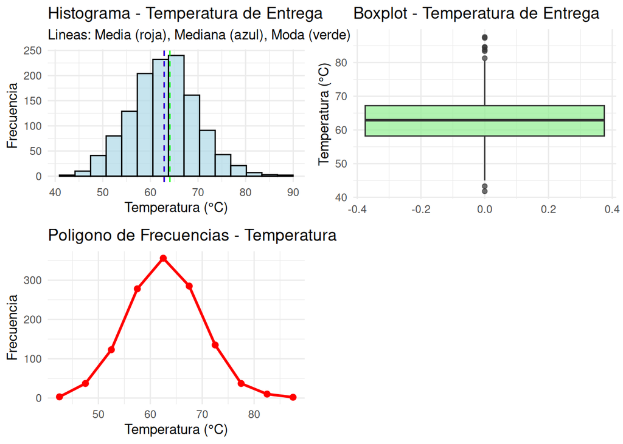

```r
# Visualizaciones
p1_temp <- ggplot(datos, aes(x = temperature)) +
  geom_histogram(bins = 15, fill = "lightblue", alpha = 0.7, color = "black") +
  geom_vline(xintercept = media_temp, color = "red", linetype = "dashed") +
  geom_vline(xintercept = mediana_temp, color = "blue", linetype = "dashed") +
  geom_vline(xintercept = moda_temp, color = "green", linetype = "dashed") +
  labs(title = "Histograma - Temperatura de Entrega",
       subtitle = "Lineas: Media (roja), Mediana (azul), Moda (verde)",
       x = "Temperatura (°C)",
       y = "Frecuencia") +
  theme_minimal()

p2_temp <- ggplot(datos, aes(y = temperature)) +
  geom_boxplot(fill = "lightgreen", alpha = 0.7) +
  labs(title = "Boxplot - Temperatura de Entrega",
       y = "Temperatura (°C)") +
  theme_minimal()

# Poligono de frecuencias
hist_data_temp <- hist(datos$temperature, plot = FALSE, breaks = 15)
polygon_data <- data.frame(
  x = hist_data_temp$mids,
  y = hist_data_temp$counts
)

p3_temp <- ggplot(polygon_data, aes(x = x, y = y)) +
  geom_line(color = "red", size = 1) +
  geom_point(color = "red", size = 2) +
  labs(title = "Poligono de Frecuencias - Temperatura",
       x = "Temperatura (°C)",
       y = "Frecuencia") +
  theme_minimal()

grid.arrange(p1_temp, p2_temp, p3_temp, ncol = 2, nrow = 2)
```

**Conclusin Problema 4:** Analisis descriptivo de la temperatura:

- **Tendencia Central**: Media = 62.86°C, Mediana = 62.9°C, Moda = 64.1°C
- **Variabilidad**: Coeficiente de variacion = 10.99%, indicando variabilidad baja
- **Distribucion**: La proximidad entre media, mediana y moda sugiere una distribucion aproximadamente simétrica

# Problema 5: Analisis de Temperatura por Dia

```r
# Analisis de temperatura por dia
temp_por_dia <- datos %>%
  group_by(day) %>%
  summarise(
    Pedidos = n(),
    Temp_Promedio = round(mean(temperature, na.rm = TRUE), 2),
    Temp_Mediana = round(median(temperature, na.rm = TRUE), 2),
    Desv_Estandar = round(sd(temperature, na.rm = TRUE), 2),
    Coef_Variacion = round((sd(temperature, na.rm = TRUE) / mean(temperature, na.rm = TRUE)) * 100, 2),
    Temp_Min = round(min(temperature, na.rm = TRUE), 2),
    Temp_Max = round(max(temperature, na.rm = TRUE), 2),
    Rango = round(max(temperature, na.rm = TRUE) - min(temperature, na.rm = TRUE), 2)
  ) %>%
  arrange(desc(Temp_Promedio))

knitr::kable(temp_por_dia, caption = "Analisis de Temperatura por Dia de la Semana")
```

Analisis de Temperatura por Dia de la Semana

| day | Pedidos | Temp_Promedio | Temp_Mediana | Desv_Estandar | Coef_Variacion | Temp_Min | Temp_Max | Rango |
| --- | --- | --- | --- | --- | --- | --- | --- | --- |
| Sunday | 177 | 64.10 | 64.10 | 7.40 | 11.55 | 46.9 | 83.4 | 36.5 |
| Tuesday | 133 | 63.79 | 63.50 | 6.71 | 10.52 | 47.6 | 84.6 | 37.0 |
| Thursday | 196 | 62.88 | 63.30 | 6.52 | 10.38 | 41.8 | 87.6 | 45.8 |
| Monday | 136 | 62.81 | 62.80 | 7.46 | 11.87 | 45.0 | 84.6 | 39.6 |
| Friday | 246 | 62.50 | 62.50 | 6.88 | 11.01 | 46.3 | 87.3 | 41.0 |
| Saturday | 246 | 62.36 | 62.40 | 6.59 | 10.56 | 46.8 | 78.8 | 32.0 |
| Wednesday | 132 | 61.92 | 62.15 | 6.83 | 11.04 | 43.3 | 80.5 | 37.2 |
| NA | 1 | NaN | NA | NA | NA | Inf | -Inf | -Inf |

```r
# Identificar dia con mayor temperatura
dia_mayor_temp <- temp_por_dia$day[1]
temp_mayor <- temp_por_dia$Temp_Promedio[1]

cat("Dia con mayor temperatura promedio:", dia_mayor_temp, "con", temp_mayor, "°C")
```

```
## Dia con mayor temperatura promedio: 7 con 64.1 °C
```

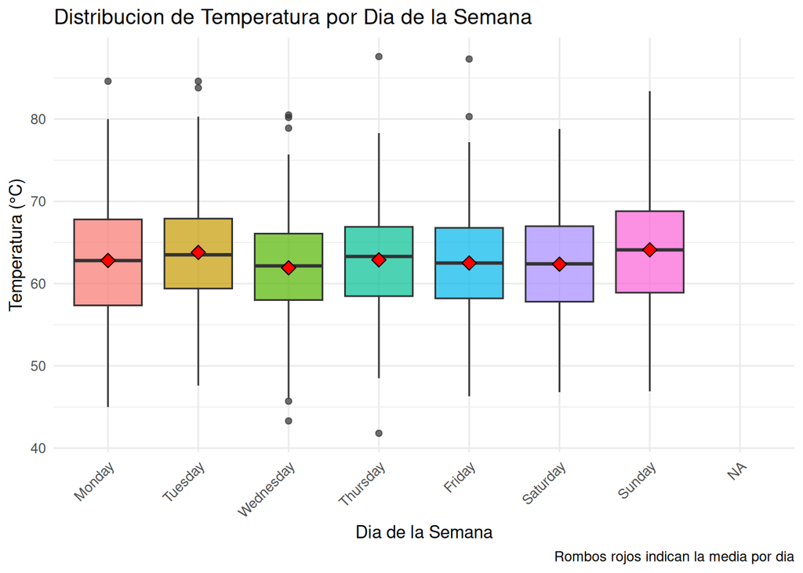

```r
# Boxplot comparativo por dia
boxplot_temp_dia <- ggplot(datos, aes(x = day, y = temperature, fill = day)) +
  geom_boxplot(alpha = 0.7) +
  stat_summary(fun = mean, geom = "point", shape = 23, size = 3, fill = "red") +
  labs(title = "Distribucion de Temperatura por Dia de la Semana",
       x = "Dia de la Semana",
       y = "Temperatura (°C)",
       caption = "Rombos rojos indican la media por dia") +
  theme_minimal() +
  theme(legend.position = "none",
        axis.text.x = element_text(angle = 45, hjust = 1))

print(boxplot_temp_dia)
```

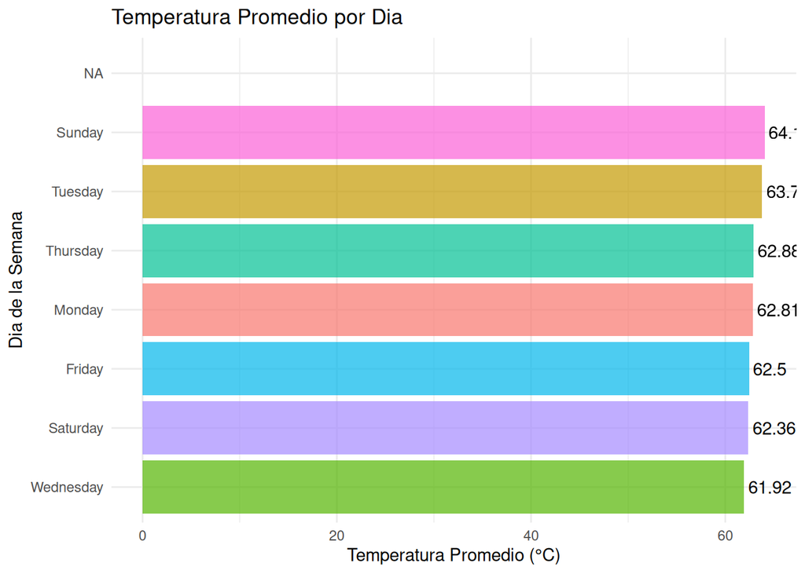

```r
# Grafica de barras para temperatura promedio
bar_temp_dia <- ggplot(temp_por_dia, aes(x = reorder(day, Temp_Promedio),
                                         y = Temp_Promedio, fill = day)) +
  geom_bar(stat = "identity", alpha = 0.7) +
  geom_text(aes(label = Temp_Promedio), hjust = -0.1) +
  labs(title = "Temperatura Promedio por Dia",
       x = "Dia de la Semana",
       y = "Temperatura Promedio (°C)") +
  theme_minimal() +
  theme(legend.position = "none") +
  coord_flip()

print(bar_temp_dia)
```

```r
# Tabla de frecuencias de temperatura por rangos para cada dia
datos$rango_temp <- cut(datos$temperature,
                       breaks = c(50, 55, 60, 65, 70),
                       labels = c("50-55°C", "55-60°C", "60-65°C", "65-70°C"),
                       include.lowest = TRUE)

freq_temp_dia <- table(datos$day, datos$rango_temp)
knitr::kable(freq_temp_dia, caption = "Frecuencias de Temperatura por Rangos y Dia")
```

Frecuencias de Temperatura por Rangos y Dia

|  | 50-55°C | 55-60°C | 60-65°C | 65-70°C |
| --- | --- | --- | --- | --- |
| Monday | 14 | 34 | 34 | 25 |
| Tuesday | 7 | 29 | 36 | 37 |
| Wednesday | 17 | 33 | 37 | 29 |
| Thursday | 19 | 43 | 55 | 52 |
| Friday | 28 | 46 | 80 | 49 |
| Saturday | 27 | 58 | 70 | 52 |
| Sunday | 13 | 35 | 44 | 41 |

**Concluson Problema 5:**

**Dia con mayor temperatura**: Sunday registro la temperatura promedio mas alta (64.1°C) durante mayo de 2014.

**Analisis detallado:** - **Variabilidad**: La variacion muestra que Thursday tiene la menor variabilidad (10.38%), indicando mayor consistencia en las temperaturas

- **Rango**: Thursday presenta el mayor rango de temperaturas (45.8°C), sugiriendo mayor variabilidad
- **Distribucion**: Los boxplots revelan que algunos dias tienen distribuciones mas simétricas que otros, con presencia de valores atipicos en ciertos dias

Este patron puede estar relacionado con factores operativos especificos del dia de la semana, como volumen de pedidos, disponibilidad de personal o procesos de cocina.